# Fit Blue Data Description

# 1 Abstract

Participants of the Fit Blue study, a weight loss study implemented at the Lackland Air Force Base, were asked to record daily diet and activity on the Lose It! application. Our objective was to investigate the effects of electronic self-monitoring behavior (using the commercial Lose It!TM application) and weight-loss interventions (with differing amounts of counselor feedback and support) on 4 and 12-month weight loss. We compared the results from two interventions of a randomized controlled trial. Counselor-initiated (CI) treatment participants received early, consistent support from interventionists, and self-paced (SP) treatment participants received assistance on request. Participants (n= 191) who were active duty military personnel were encouraged to self-monitor diet and exercise with the Lose It!TM application or website. We examined logging trends throughout the study for associations between intervention assignment and app usage. We conducted a mediation analysis of the intervention assignment on weight loss through multiple mediators: app usage (calculated from the first principal component of electronically collected variables), number of weigh-ins and 4-month weight change. We used linear regression to predict weight loss at 4 and 12 months; accuracy was measured using cross-validation. Since the app provides many variables, We performed principal components analysis to reduce data dimension and address collinearity.

# 2 Descriptive Analysis

## 2.1 Demographics

All particpants in the study were on active duty in the military and had to have at least one year left at the Air Force base so that they would likely be available in person for the 4 and 12 month follow-ups. The requirements for participation were as follows: 18 years or older, BMI greater or equal to 25.0, access to computer and email, and cleared to participate by a healthcare provider.

There were 212 total participants in this study. Only 191 records were successfully pulled from the Lose It! database.

|  | Counselor-initiated participants (n=103) | Self-paced participants (n=88) | Total(%) | P-value |
| --- | --- | --- | --- | --- |
| **Gender** |  |  |  |  |
| Female | 53(51.5%) | 46(52.3%) | 99(51.8 %) | 1 |
| Male | 50(48.5%) | 42(47.7%) | 92(48.2 %) |  |
| **Race** |  |  |  |  |
| African American | 22(21.4%) | 16(18.2%) | 38(19.9 %) |  |
| Caucasian American | 65(63.1%) | 61(69.3%) | 126(66.0 %) | 0.661 |
| Other | 16(15.5%) | 11(12.5%) | 27(14.1 %) |  |
| **Education** |  |  |  |  |
| Less than College | 46(44.7%) | 44(50%) | 90(47.1 %) | 0.554 |
| College or Above | 57(55.3%) | 44(50%) | 101(52.9 %) |  |
| **BMI Category** |  |  |  |  |
| Overweight (BMI: 25-29.9) | 51(49.5%) | 37(42%) | 88(46.1 %) | 0.375 |
| Obese (BMI: 30+) | 52(50.5%) | 51(58%) | 103(53.9 %) |  |
| **Age** |  |  |  |  |
| Age (mean, sd) | 35.5(8.2) | 33.9(6.8) | 34.8(7.6) | 0.138 |

## 2.2 Average % Days Logged-in

Login Days decreased steadily over the course of the study. Weekend and Weekday logins tended to follow the same trends with peaks and falls in the average logins. The increase at week 46 aligns with the participants’ receivals of reminder cards about the upcoming 12 month weigh-in

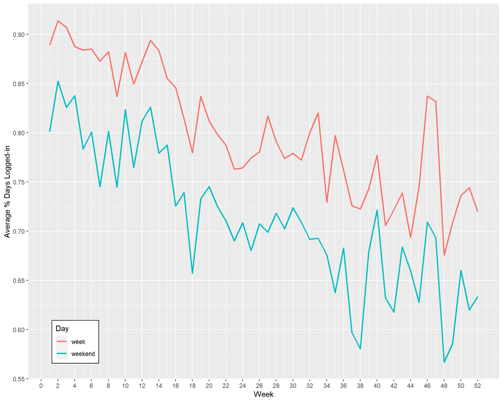

## 2.3 Number of Login Days in the First 4 Weeks

Trends within treatment groups are apparent. Counselor-initiated groups have similar login habits in the first 4 weeks while Self-paced groups have more similar login habits regardless of Success. Logins are just starting to decrease in the unsuccessful Counselor-initiated group in the fourth week which led us to believe there may be a reason to explore the first 8 weeks of the study. Another point to note is that consistent logins in the first 4 weeks didn’t seem to be a predictor of successful weight loss for Self-paced people.

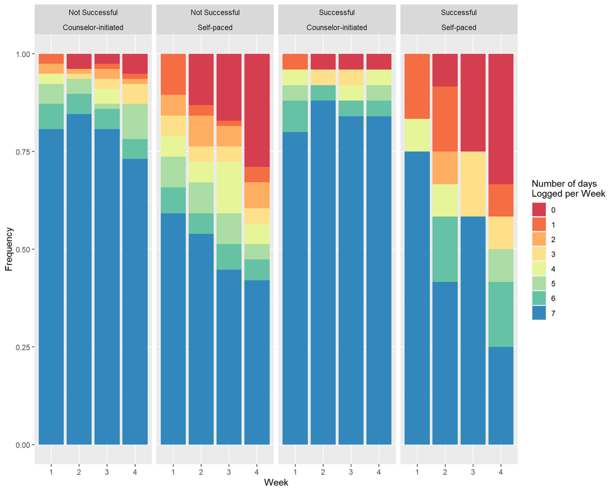

## 2.4 Number of Login Days in the first 8 weeks

- When looking at the first 8 weeks, it is easier to see the trends among groups. The Counselor-initiated Success group still looks to be the most stable in terms of days logged in
- The Self-paced Success group began to level out after the 4th week whereas the unsuccessful Self-paced group’s logins continued to decrease
- The Counselor-initiated unsuccessful group remained high in logins but there was more variability in the number of logins between weeks.

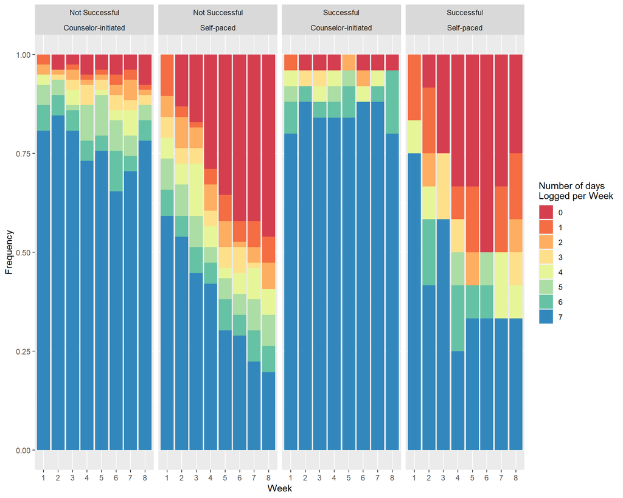

## 2.5 Number of Login Days in 4 months

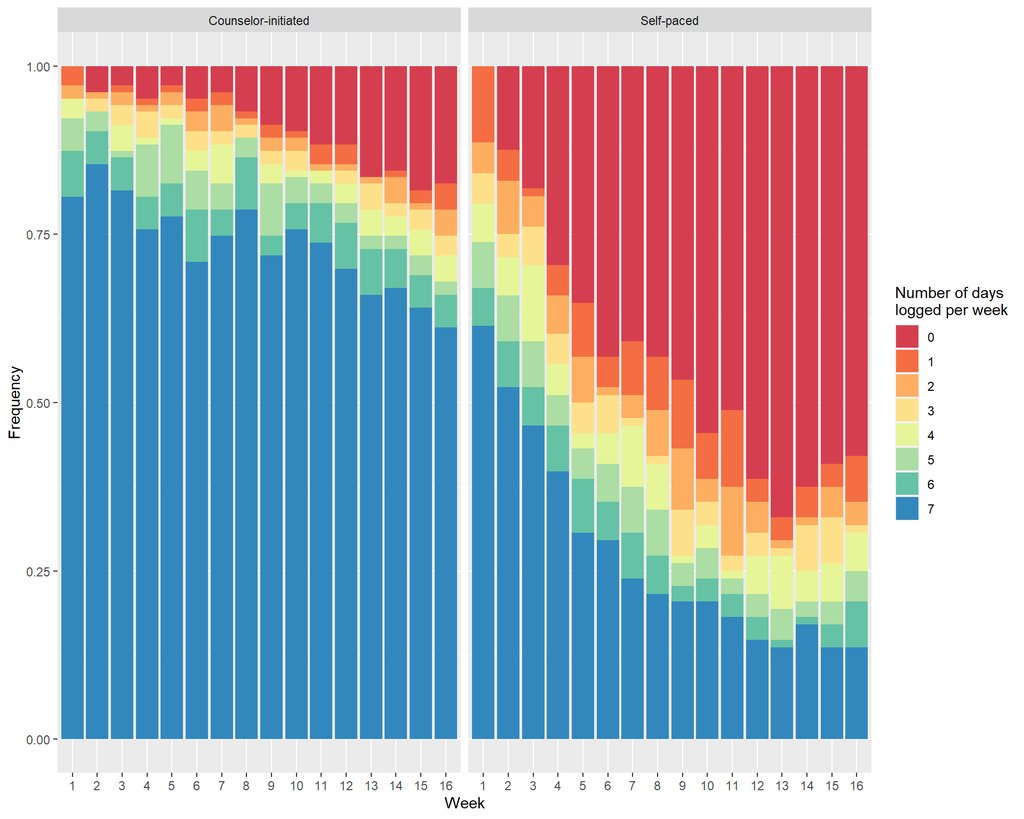